# R Notebook

7/4/21

Model selection on Phylum level glmms of relative abundance.

Overall aim of analysis is to determine which factors influence relative abundance of main phyla. Additionally we will focus on the development of the microbiome over time across the two habitat types.

For the all birds model, where the age-habitat interaction is the main variable of interest, modelling will consist of fitting a global model with all the interactions that seem biologically feasible a priori. Then non-significant interactions will be dropped and the AIC of resulting models will be compared to determine if this improves the model fit, with the aim of increasing the amount of variability explained by the non-focus terms and improving the inference of the effect of age * habitat. Therefore the age-habitat interaction will be exempt from this treatment. AIC measures the information contained in the model, and though it is normally used for improving model prediction it is a relevant model selection method here as we are attempting to increase the amount of variance explained by the model in order to improve our estimates of age * habitat. * Should non-significant fixed effects therefore also be dropped? Probably yes but i am keeping them in because i want to show the variables that have no effect. Alternatively i could carry out model selection dropping all the non-significant terms and highlighting what remains in the final model. * This (stepwise) method is expected to inflate significance terms, but will the estimates be affected?

Model selection on the adult only subset is more unclear though. Should AIC be used to select the best model for the sake of consistency? Sex-habitat interaction would be the variable of interest however our samples of adults from coniferous habitats are very low, therefore we can not trust any inference on this term to be close to the truth. The goal of this analysis is to determine which variables explain the variance in relative abundance for the two major phyla and is purely exploratory. Therefore, we should _____________

Overfitting isnt an issue as we are not using the model for prediction, therefore we arent worried about biased parameters. We are only interested in the direction of effects for significant variables*?*

25/8/21 Adding background difference coding to age variable.

# All birds Proteobacteria

```r
my.backward.diff = matrix(c(-2/3, 1/3, 1/3, -1/3, -1/3, 2/3), ncol = 2)
my.backward.diff
```

```r
levels(proteobacteria.df$ageBinned) # verify: 1week,2week,adult
#assigning the backward difference coding to ageBinned
contrasts(proteobacteria.df$ageBinned) = my.backward.diff
```

*Final model*

```r
binomial.response <- cbind(proteobacteria.df$Abundance,proteobacteria.df$NumberOfReads-proteobacteria.df$Abundance)

all.pro <- glmer(binomial.response ~  ageBinned * habitat * layDateFirst + ageBinned * broodSizeWhenSampled + habitat*DistanceToEdge +  (1|site/nest/bird.ID) + (1|SequencePlate), family= binomial, data = proteobacteria.df)

#all.pro <- glmer(binomial.response ~  ageBinned * habitat * layDateFirst + ageBinned:broodSizeWhenSampled +broodSizeWhenSampled + ageBinned:DistanceToEdge:habitat + DistanceToEdge + (1|site/nest/bird.ID) + (1|SequencePlate), family= binomial, data = proteobacteria.df, control=glmerControl(optCtrl=list(maxfun=200000)))

summary(all.pro)
```

```
Generalized linear mixed model fit by maximum likelihood (Laplace Approximation) ['glmerMod']
 Family: binomial  ( logit )
Formula: binomial.response ~ ageBinned * habitat * layDateFirst + ageBinned *      broodSizeWhenSampled + habitat * DistanceToEdge + (1 | site/nest/bird.ID) +
    (1 | SequencePlate)
   Data: proteobacteria.df

      AIC       BIC    logLik  deviance  df.resid
 548363.3  548436.9 -274160.7  548321.3       225

Scaled residuals:
     Min       1Q   Median       3Q      Max
-254.918   -0.018    0.000    0.008  159.666

Random effects:
 Groups              Name        Variance Std.Dev.
 bird.ID:(nest:site) (Intercept) 2.8934   1.7010
 nest:site           (Intercept) 1.1574   1.0758
 site                (Intercept) 0.5263   0.7255
 SequencePlate       (Intercept) 1.3622   1.1672
Number of obs: 246, groups:  bird.ID:(nest:site), 197; nest:site, 61; site, 9; SequencePlate, 5

Fixed effects:
                                        Estimate Std. Error  z value Pr(>|z|)
(Intercept)                             0.129661   0.645679    0.201  0.84084
ageBinned1                             -1.631645   0.005248 -310.909  < 2e-16 ***
ageBinned2                              2.808812   0.338161    8.306  < 2e-16 ***
habitatconifer                          0.029549   0.749716    0.039  0.96856
layDateFirst                            0.322575   0.226142    1.426  0.15375
broodSizeWhenSampled                   -0.297644   0.100130   -2.973  0.00295 **
DistanceToEdge                          0.413689   0.230203    1.797  0.07233 .
ageBinned1:habitatconifer               0.795794   0.006990  113.843  < 2e-16 ***
ageBinned2:habitatconifer              -1.726422   0.914628   -1.888  0.05908 .
ageBinned1:layDateFirst                 0.804098   0.002803  286.824  < 2e-16 ***
ageBinned2:layDateFirst                 0.504768   0.387623    1.302  0.19284
habitatconifer:layDateFirst            -0.109821   0.857325   -0.128  0.89807
ageBinned1:broodSizeWhenSampled        -0.722303   0.003251 -222.191  < 2e-16 ***
ageBinned2:broodSizeWhenSampled         0.988117   0.300326    3.290  0.00100 **
habitatconifer:DistanceToEdge          -0.218830   0.508835   -0.430  0.66715
ageBinned1:habitatconifer:layDateFirst -0.288923   0.007361  -39.251  < 2e-16 ***
ageBinned2:habitatconifer:layDateFirst -0.087765   1.413445   -0.062  0.95049
---
Signif. codes:  0 ‘***’ 0.001 ‘**’ 0.01 ‘*’ 0.05 ‘.’ 0.1 ‘ ’ 1
```

```
Correlation matrix not shown by default, as p = 17 > 12.
Use print(x, correlation=TRUE)  or
    vcov(x)        if you need it
```

Dropped habitat interaction with Distance * AIC decreases by 1.8 * use above model

```r
all.pro.1 <- glmer(binomial.response ~  ageBinned * habitat * layDateFirst + ageBinned * broodSizeWhenSampled + DistanceToEdge +  (1|site/nest/bird.ID) + (1|SequencePlate), family= binomial, data = proteobacteria.df)

summary(all.pro.1)
```

```
Generalized linear mixed model fit by maximum likelihood (Laplace Approximation) ['glmerMod']
 Family: binomial  ( logit )
Formula: binomial.response ~ ageBinned * habitat * layDateFirst + ageBinned *      broodSizeWhenSampled + DistanceToEdge + (1 | site/nest/bird.ID) +
    (1 | SequencePlate)
   Data: proteobacteria.df

      AIC       BIC    logLik  deviance  df.resid
 548361.5  548431.6 -274160.8  548321.5       226

Scaled residuals:
     Min       1Q   Median       3Q      Max
-254.918   -0.019    0.000    0.008  159.666

Random effects:
 Groups              Name        Variance Std.Dev.
 bird.ID:(nest:site) (Intercept) 2.8922   1.7007
 nest:site           (Intercept) 1.1550   1.0747
 site                (Intercept) 0.5621   0.7497
 SequencePlate       (Intercept) 1.3645   1.1681
Number of obs: 246, groups:  bird.ID:(nest:site), 197; nest:site, 61; site, 9; SequencePlate, 5

Fixed effects:
                                        Estimate Std. Error  z value Pr(>|z|)
(Intercept)                             0.134776   0.661319    0.204 0.838511
ageBinned1                             -1.631648   0.005248 -310.909  < 2e-16 ***
ageBinned2                              2.805318   0.340258    8.245  < 2e-16 ***
habitatconifer                         -0.026911   0.763495   -0.035 0.971883
layDateFirst                            0.323712   0.226772    1.427 0.153443
broodSizeWhenSampled                   -0.295107   0.099814   -2.957 0.003111 **
DistanceToEdge                          0.374420   0.212870    1.759 0.078592 .
ageBinned1:habitatconifer               0.795793   0.006990  113.843  < 2e-16 ***
ageBinned2:habitatconifer              -1.699235   0.915241   -1.857 0.063368 .
ageBinned1:layDateFirst                 0.804099   0.002803  286.824  < 2e-16 ***
ageBinned2:layDateFirst                 0.502569   0.387416    1.297 0.194551
habitatconifer:layDateFirst            -0.272026   0.805379   -0.338 0.735543
ageBinned1:broodSizeWhenSampled        -0.722302   0.003251 -222.190  < 2e-16 ***
ageBinned2:broodSizeWhenSampled         0.995736   0.299376    3.326 0.000881 ***
ageBinned1:habitatconifer:layDateFirst -0.288925   0.007361  -39.252  < 2e-16 ***
ageBinned2:habitatconifer:layDateFirst  0.070505   1.315231    0.054 0.957248
---
Signif. codes:  0 ‘***’ 0.001 ‘**’ 0.01 ‘*’ 0.05 ‘.’ 0.1 ‘ ’ 1
```

```
Correlation matrix not shown by default, as p = 16 > 12.
Use print(x, correlation=TRUE)  or
    vcov(x)        if you need it
```

Drop Distance term altogether as not significant in any fixed or interaction term * AIC decreases by 0.8 * use above model

```r
all.pro.3 <- glmer(binomial.response ~  ageBinned * habitat * layDateFirst + ageBinned * broodSizeWhenSampled +  (1|site/nest/bird.ID) + (1|SequencePlate), family= binomial, data = proteobacteria.df)
```

```
Model failed to converge with max|grad| = 0.00215423 (tol = 0.002, component 1)
```

```r
summary(all.pro.3)
```

```
Generalized linear mixed model fit by maximum likelihood (Laplace Approximation) ['glmerMod']
 Family: binomial  ( logit )
Formula: binomial.response ~ ageBinned * habitat * layDateFirst + ageBinned *      broodSizeWhenSampled + (1 | site/nest/bird.ID) + (1 | SequencePlate)
   Data: proteobacteria.df

      AIC       BIC    logLik  deviance  df.resid
 548362.5  548429.1 -274162.2  548324.5       227

Scaled residuals:
     Min       1Q   Median       3Q      Max
-254.918   -0.018    0.000    0.008  159.667

Random effects:
 Groups              Name        Variance Std.Dev.
 bird.ID:(nest:site) (Intercept) 2.8875   1.6993
 nest:site           (Intercept) 1.3565   1.1647
 site                (Intercept) 0.3776   0.6145
 SequencePlate       (Intercept) 1.3544   1.1638
Number of obs: 246, groups:  bird.ID:(nest:site), 197; nest:site, 61; site, 9; SequencePlate, 5

Fixed effects:
                                        Estimate Std. Error  z value Pr(>|z|)
(Intercept)                             0.124618   0.636757    0.196  0.84484
ageBinned1                             -1.631661   0.005248 -310.911  < 2e-16 ***
ageBinned2                              2.822851   0.341150    8.275  < 2e-16 ***
habitatconifer                          0.085447   0.714686    0.120  0.90483
layDateFirst                            0.306767   0.233914    1.311  0.18970
broodSizeWhenSampled                   -0.306378   0.101252   -3.026  0.00248 **
ageBinned1:habitatconifer               0.795808   0.006990  113.845  < 2e-16 ***
ageBinned2:habitatconifer              -1.768465   0.913110   -1.937  0.05278 .
ageBinned1:layDateFirst                 0.804106   0.002803  286.827  < 2e-16 ***
ageBinned2:layDateFirst                 0.414349   0.385917    1.074  0.28297
habitatconifer:layDateFirst             0.119568   0.765204    0.156  0.87583
ageBinned1:broodSizeWhenSampled        -0.722302   0.003251 -222.190  < 2e-16 ***
ageBinned2:broodSizeWhenSampled         0.961932   0.303690    3.167  0.00154 **
ageBinned1:habitatconifer:layDateFirst -0.288935   0.007361  -39.253  < 2e-16 ***
ageBinned2:habitatconifer:layDateFirst -0.129308   1.353623   -0.096  0.92390
---
Signif. codes:  0 ‘***’ 0.001 ‘**’ 0.01 ‘*’ 0.05 ‘.’ 0.1 ‘ ’ 1
```

```
Correlation matrix not shown by default, as p = 15 > 12.
Use print(x, correlation=TRUE)  or
    vcov(x)        if you need it
```

```
optimizer (Nelder_Mead) convergence code: 0 (OK)
Model failed to converge with max|grad| = 0.00215423 (tol = 0.002, component 1)
```

Model validation * ensure running with final model * significant deviation * check over-dispersion: seems fine * check outliers: seems fine * check individual predictors: not fine, transform predictors

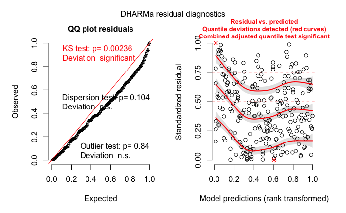

```r
simulationOutput <- simulateResiduals(fittedModel = all.pro, n = 250)
plot(simulationOutput)
```

Plot residuals against individual predictors

[figure not shown]

```
    DHARMa zero-inflation test via comparison to expected zeros with simulation under H0 = fitted model

data:  simulationOutput
ratioObsSim = 0, p-value = 1
alternative hypothesis: two.sided
```

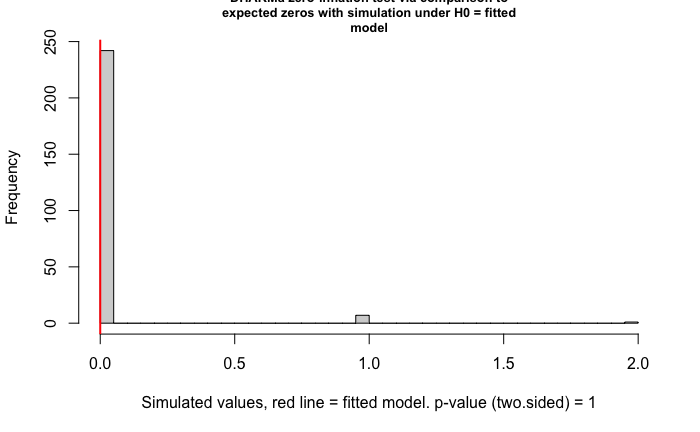

```r
testZeroInflation(simulationOutput)
```

Transform predictors * sqrt laydate: fails to converge (but note residuals much improved), sqrt of negative values gives NAs

```r
binomial.response <- cbind(proteobacteria.df$Abundance,proteobacteria.df$NumberOfReads-proteobacteria.df$Abundance)

all.pro <- glmer(binomial.response ~  ageBinned * habitat * I(sqrt(layDateFirst)) + ageBinned * broodSizeWhenSampled + habitat*DistanceToEdge +  (1|site/nest/bird.ID) + (1|SequencePlate), family= binomial, data = proteobacteria.df)

summary(all.pro)
```

```r
simulationOutput.edit <- simulateResiduals(fittedModel = all.pro, n = 250)
plot(simulationOutput.edit)
```

[output not shown]

```r
plotResiduals(simulationOutput.edit, form = metadata.scaled$ageBinned) #fine
plotResiduals(simulationOutput.edit, form = metadata.scaled$habitat) #fine
plotResiduals(simulationOutput.edit, form = metadata.scaled$layDateFirst) #pattern
plotResiduals(simulationOutput.edit, form = metadata.scaled$broodSizeWhenSampled) #residuals larger than expected for low values of BS
plotResiduals(simulationOutput.edit, form = metadata.scaled$DistanceToEdge) #pattern
```

Fit model w/i random effect groupings (site and sequence plate)

```r
#unique(proteobacteria.df$site) # BP CB DW FR GT IN KB LS SP
mydata <- subset(proteobacteria.df, proteobacteria.df$site == "BP")
mydata <- subset(proteobacteria.df, proteobacteria.df$SequencePlate == "04/10/2018")

binomial.response.mydata <- cbind(mydata$Abundance,mydata$NumberOfReads-mydata$Abundance)

all.pro <- glmer(binomial.response.mydata ~  ageBinned *habitat* layDateFirst + ageBinned * broodSizeWhenSampled + habitat*DistanceToEdge +  (1|site/nest/bird.ID) , family= binomial, data = mydata)

summary(all.pro)
```

Check residuals for random effects ie refit each model by group * error maybe due to NAs in predictor or response? * possible to refit with only one site? As then habitat has only 1 level

```r
unique(is.na(proteobacteria.df$habitat))
simulationOutput <- recalculateResiduals(simulationOutput.edit, group = proteobacteria.df$SequencePlate)
```

# All birds: Firmicutes

```r
my.backward.diff = matrix(c(-2/3, 1/3, 1/3, -1/3, -1/3, 2/3), ncol = 2)
my.backward.diff
```

```
           [,1]       [,2]
[1,] -0.6666667 -0.3333333
[2,]  0.3333333 -0.3333333
[3,]  0.3333333  0.6666667
```

```r
levels(firmicutes.df$ageBinned) # verify: 1week,2week,adult
```

```
[1] "1week" "2week" "adult"
```

```r
#assigning the backward difference coding to ageBinned
contrasts(firmicutes.df$ageBinned) = my.backward.diff
```

Global model * Model fails to converge * ALso fails to converge with different optimizer

```r
binomial.response <- cbind(firmicutes.df$Abundance,firmicutes.df$NumberOfReads-firmicutes.df$Abundance)

all.fir <- glmer(binomial.response ~  ageBinned * habitat * layDateFirst + ageBinned * broodSizeWhenSampled + habitat*DistanceToEdge +  (1|site/nest/bird.ID) + (1|SequencePlate), family= binomial, data = firmicutes.df)#, glmerControl(optimizer = "bobyqa", optCtrl = list(maxfun = 10000000)))
```

```
Model is nearly unidentifiable: large eigenvalue ratio
 - Rescale variables?
```

```r
summary(all.fir)
```

```
Generalized linear mixed model fit by maximum likelihood (Laplace Approximation) ['glmerMod']
 Family: binomial  ( logit )
Formula: binomial.response ~ ageBinned * habitat * layDateFirst + ageBinned *      broodSizeWhenSampled + habitat * DistanceToEdge + (1 | site/nest/bird.ID) +
    (1 | SequencePlate)
   Data: firmicutes.df

      AIC       BIC    logLik  deviance  df.resid
 741292.1  741365.8 -370625.1  741250.1       225

Scaled residuals:
    Min      1Q  Median      3Q     Max
-214.03   -0.02    0.00    0.01  276.48

Random effects:
 Groups              Name        Variance Std.Dev.
 bird.ID:(nest:site) (Intercept) 3.5310   1.8791
 nest:site           (Intercept) 1.9818   1.4078
 site                (Intercept) 0.9003   0.9489
 SequencePlate       (Intercept) 1.2020   1.0963
Number of obs: 246, groups:  bird.ID:(nest:site), 197; nest:site, 61; site, 9; SequencePlate, 5

Fixed effects:
                                        Estimate Std. Error  z value Pr(>|z|)
(Intercept)                            -2.124646   0.729819   -2.911 0.003600 **
ageBinned1                              1.631548   0.005022  324.850  < 2e-16 ***
ageBinned2                             -3.270343   0.383593   -8.526  < 2e-16 ***
habitatconifer                         -0.054525   0.994588   -0.055 0.956280
layDateFirst                           -0.269242   0.280628   -0.959 0.337342
broodSizeWhenSampled                    0.429893   0.114615    3.751 0.000176 ***
DistanceToEdge                         -0.069038   0.279291   -0.247 0.804762
ageBinned1:habitatconifer              -1.832069   0.006450 -284.055  < 2e-16 ***
ageBinned2:habitatconifer               1.819272   1.065180    1.708 0.087646 .
ageBinned1:layDateFirst                -0.711511   0.002691 -264.422  < 2e-16 ***
ageBinned2:layDateFirst                -0.405771   0.430475   -0.943 0.345879
habitatconifer:layDateFirst             0.044953   1.066798    0.042 0.966389
ageBinned1:broodSizeWhenSampled         0.833244   0.003011  276.696  < 2e-16 ***
ageBinned2:broodSizeWhenSampled        -0.635640   0.343788   -1.849 0.064468 .
habitatconifer:DistanceToEdge           0.645505   0.641323    1.007 0.314166
ageBinned1:habitatconifer:layDateFirst  0.153297   0.006606   23.207  < 2e-16 ***
ageBinned2:habitatconifer:layDateFirst  1.405116   1.669029    0.842 0.399857
---
Signif. codes:  0 ‘***’ 0.001 ‘**’ 0.01 ‘*’ 0.05 ‘.’ 0.1 ‘ ’ 1
```

```
Correlation matrix not shown by default, as p = 17 > 12.
Use print(x, correlation=TRUE)  or
    vcov(x)        if you need it
```

```
optimizer (Nelder_Mead) convergence code: 0 (OK)
Model is nearly unidentifiable: large eigenvalue ratio
 - Rescale variables?
```

check correlation of variables

```r
vcov(all.fir)
```

[output not shown]

[output cut: 18 more lines]

[output not shown]

```r
max(vcov(all.fir))
```

```
[1] 2.785658
```

Dropping habitat interaction with distance fixes model WARNING above *final model* * residuals poor

```r
binomial.response <- cbind(firmicutes.df$Abundance,firmicutes.df$NumberOfReads-firmicutes.df$Abundance)

all.fir.2 <- glmer(binomial.response ~  ageBinned * habitat * layDateFirst + ageBinned * broodSizeWhenSampled + DistanceToEdge +  (1|site/nest/bird.ID) + (1|SequencePlate), family= binomial, data = firmicutes.df) # fits well

summary(all.fir.2)
```

```
Generalized linear mixed model fit by maximum likelihood (Laplace Approximation) ['glmerMod']
 Family: binomial  ( logit )
Formula: binomial.response ~ ageBinned * habitat * layDateFirst + ageBinned *      broodSizeWhenSampled + DistanceToEdge + (1 | site/nest/bird.ID) +
    (1 | SequencePlate)
   Data: firmicutes.df

      AIC       BIC    logLik  deviance  df.resid
 741291.2  741361.3 -370625.6  741251.2       226

Scaled residuals:
     Min       1Q   Median       3Q      Max
-214.026   -0.021    0.001    0.010  276.480

Random effects:
 Groups              Name        Variance Std.Dev.
 bird.ID:(nest:site) (Intercept) 3.5309   1.8791
 nest:site           (Intercept) 2.0702   1.4388
 site                (Intercept) 0.8224   0.9068
 SequencePlate       (Intercept) 1.1993   1.0951
Number of obs: 246, groups:  bird.ID:(nest:site), 197; nest:site, 61; site, 9; SequencePlate, 5

Fixed effects:
                                        Estimate Std. Error  z value Pr(>|z|)
(Intercept)                            -2.114802   0.701162   -3.016 0.002560 **
ageBinned1                              1.631553   0.005022  324.852  < 2e-16 ***
ageBinned2                             -3.273553   0.382454   -8.559  < 2e-16 ***
habitatconifer                          0.099334   0.929528    0.107 0.914896
layDateFirst                           -0.260554   0.281432   -0.926 0.354541
broodSizeWhenSampled                    0.425215   0.114945    3.699 0.000216 ***
DistanceToEdge                          0.062215   0.252557    0.246 0.805420
ageBinned1:habitatconifer              -1.832069   0.006450 -284.056  < 2e-16 ***
ageBinned2:habitatconifer               1.762678   1.034569    1.704 0.088422 .
ageBinned1:layDateFirst                -0.711512   0.002691 -264.422  < 2e-16 ***
ageBinned2:layDateFirst                -0.389530   0.430426   -0.905 0.365472
habitatconifer:layDateFirst             0.488090   0.922407    0.529 0.596703
ageBinned1:broodSizeWhenSampled         0.833245   0.003011  276.697  < 2e-16 ***
ageBinned2:broodSizeWhenSampled        -0.649690   0.344779   -1.884 0.059516 .
ageBinned1:habitatconifer:layDateFirst  0.153300   0.006606   23.208  < 2e-16 ***
ageBinned2:habitatconifer:layDateFirst  0.999511   1.581102    0.632 0.527282
---
Signif. codes:  0 ‘***’ 0.001 ‘**’ 0.01 ‘*’ 0.05 ‘.’ 0.1 ‘ ’ 1
```

```
Correlation matrix not shown by default, as p = 16 > 12.
Use print(x, correlation=TRUE)  or
    vcov(x)        if you need it
```

Drop distance variable as not significant as fixed term * model nearly unidentifiable * AIC decreases by 2 *BUT i said i would keep these non-significant fixed terms*

```r
binomial.response <- cbind(firmicutes.df$Abundance,firmicutes.df$NumberOfReads-firmicutes.df$Abundance)

all.fir.3 <- glmer(binomial.response ~  ageBinned * habitat * layDateFirst + ageBinned * broodSizeWhenSampled +  (1|site/nest/bird.ID) + (1|SequencePlate), family= binomial, data = firmicutes.df) # fits well

summary(all.fir.3)
```

Drop laydate interaction, even tho its significant * AIC increases alot * AIC also increases if age*BS interaction dropped

```r
binomial.response <- cbind(firmicutes.df$Abundance,firmicutes.df$NumberOfReads-firmicutes.df$Abundance)

all.fir <- glmer(binomial.response ~  ageBinned * habitat + layDateFirst + ageBinned * broodSizeWhenSampled + DistanceToEdge +  (1|site/nest/bird.ID) + (1|SequencePlate), family= binomial, data = firmicutes.df) # fits well

summary(all.fir)
```

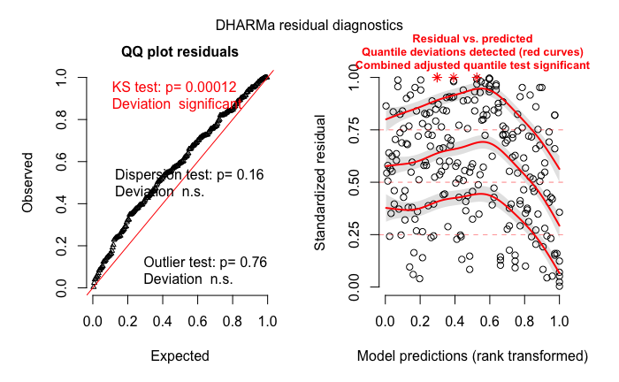

```r
simulationOutput <- simulateResiduals(fittedModel = all.fir.2, n = 250)
plot(simulationOutput)
```

[figure not shown]

#Adult birds: Proteobacteria

calc correlation cooefficent for all covariates and RA

```r
cor((proteobacteria.df.adult$Abundance/(proteobacteria.df.adult$NumberOfReads-proteobacteria.df.adult$Abundance)), proteobacteria.df.adult$site )
```

```
Error in cor((proteobacteria.df.adult$Abundance/(proteobacteria.df.adult$NumberOfReads -  :
  'y' must be numeric
```

Boxplot of sex-habitat for proteobacteria. * Note: only 4 coniferous males, 3 coniferous females

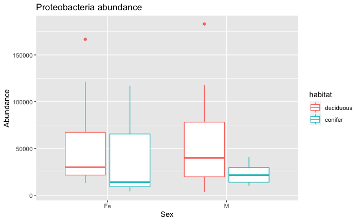

```r
ggplot(proteobacteria.df.adult, aes(Sex, Abundance, color=habitat)) +
  geom_boxplot() +
  ggtitle("Proteobacteria abundance")
```

At first i intended on focussing on Sex*habitat as a term of main interest however this gave conflicting results (term highly significant OR highly non-significant depending on model formula), on reflection this is probably de to small n of adult-conifer. So will proceed with a particular term or variable of interest but will focus more on exploration. AIC will be used as model selection technique to remain consisitent with all-birds model.

Full model (mirror of alpha-div model) converges * added Sex interaction with habitat*laydate as seems like it would be important and residuals improve

```r
#proteobacteria.df.adult <- proteobacteria.df.adult[!proteobacteria.df.adult$BIOM.ID=="SP7M.S10",] # extreme outlier for distance
binomial.response <- cbind(proteobacteria.df.adult$Abundance,proteobacteria.df.adult$NumberOfReads-proteobacteria.df.adult$Abundance)

adu.pro.1 <- glmer(binomial.response ~ Sex * habitat * broodSizeWhenSampled + habitat * layDateFirst * Sex + habitat * DistanceToEdge + (1|site/nest) + (1|SequencePlate), family= binomial, data = proteobacteria.df.adult) # singular fit

summary(adu.pro.1)
```

```
Generalized linear mixed model fit by maximum likelihood (Laplace Approximation) ['glmerMod']
 Family: binomial  ( logit )
Formula: binomial.response ~ Sex * habitat * broodSizeWhenSampled + habitat *
    layDateFirst * Sex + habitat * DistanceToEdge + (1 | site/nest) +      (1 | SequencePlate)
   Data: proteobacteria.df.adult

     AIC      BIC   logLik deviance df.resid
 90075.6  90108.5 -45020.8  90041.6       34

Scaled residuals:
     Min       1Q   Median       3Q      Max
-126.091   -0.008    0.000    0.032  204.155

Random effects:
 Groups        Name        Variance Std.Dev.
 nest:site     (Intercept) 2.68173  1.6376
 site          (Intercept) 0.05753  0.2399
 SequencePlate (Intercept) 0.20628  0.4542
Number of obs: 51, groups:  nest:site, 38; site, 8; SequencePlate, 4

Fixed effects:
                                          Estimate Std. Error z value Pr(>|z|)
(Intercept)                               1.334735   0.392133   3.404 0.000665 ***
SexM                                      0.147735   0.006001  24.617  < 2e-16 ***
habitatconifer                           -2.495501   1.780417  -1.402 0.161023
broodSizeWhenSampled                     -1.253916   0.039655 -31.621  < 2e-16 ***
layDateFirst                             -0.036134   0.338202  -0.107 0.914915
DistanceToEdge                           -0.284627   0.296239  -0.961 0.336653
SexM:habitatconifer                       1.934772   2.176004   0.889 0.373928
SexM:broodSizeWhenSampled                 2.095916   0.011824 177.252  < 2e-16 ***
habitatconifer:broodSizeWhenSampled      -3.476188   1.782767  -1.950 0.051190 .
habitatconifer:layDateFirst              -0.724849   2.824488  -0.257 0.797464
SexM:layDateFirst                         0.910679   0.009859  92.370  < 2e-16 ***
habitatconifer:DistanceToEdge             0.370248   1.043900   0.355 0.722831
SexM:habitatconifer:broodSizeWhenSampled  2.496927   1.555771   1.605 0.108506
SexM:habitatconifer:layDateFirst          0.574086   1.988764   0.289 0.772838
---
Signif. codes:  0 ‘***’ 0.001 ‘**’ 0.01 ‘*’ 0.05 ‘.’ 0.1 ‘ ’ 1
```

```
Correlation matrix not shown by default, as p = 14 > 12.
Use print(x, correlation=TRUE)  or
    vcov(x)        if you need it
```

See outlier- is it the Distance outlier SP7M?

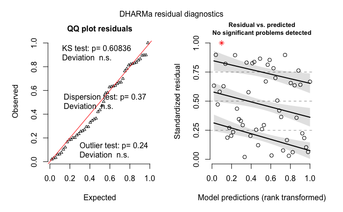

```r
simOut <- simulateResiduals(adu.pro, n = 1000)
plot(simOut)
```

Drop habitat interaction with Sex * laydate as least significant 3-way interaction, and habitat * lay date not significant * AIC drops by 3.9

```r
#proteobacteria.df.adult <- proteobacteria.df.adult[!proteobacteria.df.adult$BIOM.ID=="SP7M.S10",] # extreme outlier for distance
binomial.response <- cbind(proteobacteria.df.adult$Abundance,proteobacteria.df.adult$NumberOfReads-proteobacteria.df.adult$Abundance)

adu.pro.2 <- glmer(binomial.response ~ Sex * habitat * broodSizeWhenSampled + layDateFirst * Sex + habitat * DistanceToEdge + (1|site/nest) + (1|SequencePlate), family= binomial, data = proteobacteria.df.adult) # singular fit

summary(adu.pro.2)
```

```
Generalized linear mixed model fit by maximum likelihood (Laplace Approximation) ['glmerMod']
 Family: binomial  ( logit )
Formula: binomial.response ~ Sex * habitat * broodSizeWhenSampled + layDateFirst *
    Sex + habitat * DistanceToEdge + (1 | site/nest) + (1 | SequencePlate)
   Data: proteobacteria.df.adult

     AIC      BIC   logLik deviance df.resid
 90071.7  90100.7 -45020.9  90041.7       36

Scaled residuals:
     Min       1Q   Median       3Q      Max
-126.091   -0.008   -0.001    0.033  204.155

Random effects:
 Groups        Name        Variance Std.Dev.
 nest:site     (Intercept) 2.68685  1.6392
 site          (Intercept) 0.05912  0.2432
 SequencePlate (Intercept) 0.20634  0.4542
Number of obs: 51, groups:  nest:site, 38; site, 8; SequencePlate, 4

Fixed effects:
                                          Estimate Std. Error z value Pr(>|z|)
(Intercept)                               1.334948   0.392357   3.402 0.000668 ***
SexM                                      0.147739   0.006001  24.617  < 2e-16 ***
habitatconifer                           -2.060310   0.956187  -2.155 0.031184 *
broodSizeWhenSampled                     -1.253944   0.039655 -31.621  < 2e-16 ***
layDateFirst                             -0.039926   0.332028  -0.120 0.904287
DistanceToEdge                           -0.284949   0.296011  -0.963 0.335733
SexM:habitatconifer                       1.315144   0.425388   3.092 0.001991 **
SexM:broodSizeWhenSampled                 2.095914   0.011825 177.251  < 2e-16 ***
habitatconifer:broodSizeWhenSampled      -3.150833   1.260534  -2.500 0.012433 *
SexM:layDateFirst                         0.910695   0.009859  92.373  < 2e-16 ***
habitatconifer:DistanceToEdge             0.541535   0.768647   0.705 0.481103
SexM:habitatconifer:broodSizeWhenSampled  2.357240   1.451329   1.624 0.104334
---
Signif. codes:  0 ‘***’ 0.001 ‘**’ 0.01 ‘*’ 0.05 ‘.’ 0.1 ‘ ’ 1

Correlation of Fixed Effects:
            (Intr) SexM   hbttcn brdSWS lyDtFr DstnTE SxM:hb SM:SWS hb:SWS SxM:DF hb:DTE
SexM        -0.003
habitatcnfr -0.284  0.002
brdSzWhnSmp -0.009  0.048  0.006
layDateFrst -0.092 -0.007  0.140  0.017
DistancTEdg -0.034  0.000  0.036  0.010  0.184
SxM:hbttcnf  0.001 -0.006 -0.603 -0.005 -0.043  0.000
SxM:brdSzWS -0.006 -0.028  0.002  0.488  0.003  0.003  0.001
hbttcnf:SWS -0.009 -0.003  0.399 -0.030  0.113  0.015 -0.855 -0.015
SxM:lyDtFrs  0.000  0.329 -0.003 -0.234 -0.022 -0.002  0.019  0.016  0.005
hbttcnf:DTE  0.009  0.001 -0.045 -0.004  0.048 -0.374  0.078 -0.004 -0.115 -0.002
SxM:hbt:SWS  0.001  0.001 -0.603 -0.003 -0.043  0.000  0.999 -0.008 -0.855  0.000  0.079
```

Drop habitat interaction from habitat*distance in adu.pro.2, as it least significant interaction term* AIC drops by 1.5

```r
#proteobacteria.df.adult <- proteobacteria.df.adult[!proteobacteria.df.adult$BIOM.ID=="SP7M.S10",] # extreme outlier for distance
binomial.response <- cbind(proteobacteria.df.adult$Abundance,proteobacteria.df.adult$NumberOfReads-proteobacteria.df.adult$Abundance)

adu.pro.3 <- glmer(binomial.response ~ Sex * habitat * broodSizeWhenSampled + layDateFirst * Sex + DistanceToEdge + (1|site/nest) + (1|SequencePlate), family= binomial, data = proteobacteria.df.adult) # singular fit

summary(adu.pro.3)
```

Separate out 3 way sex*habitat*broodSize into 3 2-way interactions from adu.pro.2 * AIC increases by 0.6

```r
#proteobacteria.df.adult <- proteobacteria.df.adult[!proteobacteria.df.adult$BIOM.ID=="SP7M.S10",] # extreme outlier for distance
binomial.response <- cbind(proteobacteria.df.adult$Abundance,proteobacteria.df.adult$NumberOfReads-proteobacteria.df.adult$Abundance)

adu.pro.4 <- glmer(binomial.response ~ Sex * habitat + habitat * broodSizeWhenSampled + Sex * broodSizeWhenSampled+ layDateFirst * Sex + habitat * DistanceToEdge + (1|site/nest) + (1|SequencePlate), family= binomial, data = proteobacteria.df.adult)

summary(adu.pro.4)
```

Separate out 3 way sex*habitat*laydate into 2 2-way interactions * model fails to converge

```r
#proteobacteria.df.adult <- proteobacteria.df.adult[!proteobacteria.df.adult$BIOM.ID=="SP7M.S10",] # extreme outlier for distance
binomial.response <- cbind(proteobacteria.df.adult$Abundance,proteobacteria.df.adult$NumberOfReads-proteobacteria.df.adult$Abundance)

adu.pro.5 <- glmer(binomial.response ~ Sex * habitat * broodSizeWhenSampled + habitat * layDateFirst + layDateFirst * Sex + habitat * DistanceToEdge + (1|site/nest) + (1|SequencePlate), family= binomial, data = proteobacteria.df.adult)

summary(adu.pro.5)
```

Separate out Sex * habitat * broodSizeWhenSampled * singular fit * AIC increases by almost 40,000

```r
#proteobacteria.df.adult <- proteobacteria.df.adult[!proteobacteria.df.adult$BIOM.ID=="SP7M.S10",] # extreme outlier for distance
binomial.response <- cbind(proteobacteria.df.adult$Abundance,proteobacteria.df.adult$NumberOfReads-proteobacteria.df.adult$Abundance)

adu.pro.6 <- glmer(binomial.response ~ Sex * habitat + habitat * broodSizeWhenSampled + habitat * layDateFirst + layDateFirst * Sex + habitat * DistanceToEdge + (1|site/nest) + (1|SequencePlate), family= binomial, data = proteobacteria.df.adult) # singular fit

summary(adu.pro.6)
```

Drop distance term from adu.pro.2 (AIC 90071.7) as non-significant in fixed and interaction terms * AIC drops by 2.9 *final model*

```r
#proteobacteria.df.adult <- proteobacteria.df.adult[!proteobacteria.df.adult$BIOM.ID=="SP7M.S10",] # extreme outlier for distance
binomial.response <- cbind(proteobacteria.df.adult$Abundance,proteobacteria.df.adult$NumberOfReads-proteobacteria.df.adult$Abundance)

adu.pro.7 <- glmer(binomial.response ~ Sex * habitat * broodSizeWhenSampled + layDateFirst * Sex + (1|site/nest) + (1|SequencePlate), family= binomial, data = proteobacteria.df.adult) # singular fit

summary(adu.pro.7)
```

```
Generalized linear mixed model fit by maximum likelihood (Laplace Approximation) ['glmerMod']
 Family: binomial  ( logit )
Formula: binomial.response ~ Sex * habitat * broodSizeWhenSampled + layDateFirst *      Sex + (1 | site/nest) + (1 | SequencePlate)
   Data: proteobacteria.df.adult

     AIC      BIC   logLik deviance df.resid
 90068.8  90093.9 -45021.4  90042.8       38

Scaled residuals:
     Min       1Q   Median       3Q      Max
-126.097   -0.008   -0.001    0.032  204.154

Random effects:
 Groups        Name        Variance Std.Dev.
 nest:site     (Intercept) 2.7220   1.6498
 site          (Intercept) 0.1089   0.3300
 SequencePlate (Intercept) 0.2077   0.4557
Number of obs: 51, groups:  nest:site, 38; site, 8; SequencePlate, 4

Fixed effects:
                                          Estimate Std. Error z value Pr(>|z|)
(Intercept)                               1.322251   0.408082   3.240  0.00119 **
SexM                                      0.147733   0.006001  24.616  < 2e-16 ***
habitatconifer                           -2.017935   0.976933  -2.066  0.03887 *
broodSizeWhenSampled                     -1.253755   0.039658 -31.614  < 2e-16 ***
layDateFirst                              0.005423   0.327864   0.017  0.98680
SexM:habitatconifer                       1.303328   0.428926   3.039  0.00238 **
SexM:broodSizeWhenSampled                 2.095944   0.011825 177.244  < 2e-16 ***
habitatconifer:broodSizeWhenSampled      -3.083752   1.274551  -2.419  0.01554 *
SexM:layDateFirst                         0.910697   0.009859  92.373  < 2e-16 ***
SexM:habitatconifer:broodSizeWhenSampled  2.316803   1.463388   1.583  0.11338
---
Signif. codes:  0 ‘***’ 0.001 ‘**’ 0.01 ‘*’ 0.05 ‘.’ 0.1 ‘ ’ 1

Correlation of Fixed Effects:
            (Intr) SexM   hbttcn brdSWS lyDtFr SxM:hb SM:SWS hb:SWS SxM:DF
SexM        -0.003
habitatcnfr -0.296  0.002
brdSzWhnSmp -0.009  0.048  0.005
layDateFrst -0.085 -0.007  0.139  0.017
SxM:hbttcnf -0.002 -0.006 -0.593 -0.004 -0.053
SxM:brdSzWS -0.006 -0.028  0.002  0.488  0.003  0.002
hbttcnf:SWS -0.004 -0.002  0.393 -0.032  0.125 -0.855 -0.016
SxM:lyDtFrs  0.000  0.329 -0.003 -0.234 -0.022  0.019  0.016  0.005
SxM:hbt:SWS -0.002  0.001 -0.593 -0.002 -0.052  0.999 -0.007 -0.855  0.000
```

```r
#proteobacteria.df.adult <- proteobacteria.df.adult[!proteobacteria.df.adult$BIOM.ID=="SP7M.S10",] # extreme outlier for distance
binomial.response <- cbind(proteobacteria.df.adult$Abundance,proteobacteria.df.adult$NumberOfReads-proteobacteria.df.adult$Abundance)

adu.pro.8 <- glmer(binomial.response ~ Sex * habitat + Sex * broodSizeWhenSampled +habitat * broodSizeWhenSampled + layDateFirst * Sex + (1|site/nest) + (1|SequencePlate), family= binomial, data = proteobacteria.df.adult)

summary(adu.pro.8)
```

```
Generalized linear mixed model fit by maximum likelihood (Laplace Approximation) ['glmerMod']
 Family: binomial  ( logit )
Formula: binomial.response ~ Sex * habitat + Sex * broodSizeWhenSampled +      habitat * broodSizeWhenSampled + layDateFirst * Sex + (1 |
    site/nest) + (1 | SequencePlate)
   Data: proteobacteria.df.adult

     AIC      BIC   logLik deviance df.resid
 90069.2  90092.4 -45022.6  90045.2       39

Scaled residuals:
     Min       1Q   Median       3Q      Max
-126.110   -0.007   -0.001    0.027  204.151

Random effects:
 Groups        Name        Variance Std.Dev.
 nest:site     (Intercept) 2.94462  1.7160
 site          (Intercept) 0.06702  0.2589
 SequencePlate (Intercept) 0.20760  0.4556
Number of obs: 51, groups:  nest:site, 38; site, 8; SequencePlate, 4

Fixed effects:
                                     Estimate Std. Error z value Pr(>|z|)
(Intercept)                          1.326301   0.405936   3.267  0.00109 **
SexM                                 0.147722   0.006002  24.614  < 2e-16 ***
habitatconifer                      -1.104180   0.797644  -1.384  0.16627
broodSizeWhenSampled                -1.254086   0.039685 -31.601  < 2e-16 ***
layDateFirst                         0.032891   0.338376   0.097  0.92256
SexM:habitatconifer                  0.624778   0.016583  37.676  < 2e-16 ***
SexM:broodSizeWhenSampled            2.096015   0.011828 177.202  < 2e-16 ***
habitatconifer:broodSizeWhenSampled -1.367756   0.681052  -2.008  0.04461 *
SexM:layDateFirst                    0.910724   0.009859  92.373  < 2e-16 ***
---
Signif. codes:  0 ‘***’ 0.001 ‘**’ 0.01 ‘*’ 0.05 ‘.’ 0.1 ‘ ’ 1

Correlation of Fixed Effects:
            (Intr) SexM   hbttcn brdSWS lyDtFr SxM:hb SM:SWS hb:SWS
SexM        -0.003
habitatcnfr -0.360  0.003
brdSzWhnSmp -0.009  0.048  0.004
layDateFrst -0.090 -0.007  0.137  0.015
SxM:hbttcnf  0.000 -0.171 -0.011 -0.055 -0.010
SxM:brdSzWS -0.006 -0.028 -0.003  0.489  0.002  0.229
hbttcnf:SWS -0.018 -0.003 -0.279 -0.061  0.158 -0.005 -0.040
SxM:lyDtFrs  0.000  0.329 -0.003 -0.234 -0.021  0.484  0.016  0.009
```

#Adult birds: Firmicutes

```r
ggplot(firmicutes.df.adult, aes(Sex, Abundance, color=habitat)) +
  geom_boxplot() +
  ggtitle("Firmicutes abundance: Adult")
```

[output not shown]

Global adult firmicutes * residuals poor * final variable list, transform to improve residuals?

```r
#firmicutes.df.adult <- subset(firmicutes.df.adult, !BIOM.ID=="SP7M.S10")
binomial.response <- cbind(firmicutes.df.adult$Abundance,firmicutes.df.adult$NumberOfReads-firmicutes.df.adult$Abundance)

adu.fir <- glmer(binomial.response ~  Sex * habitat * broodSizeWhenSampled + habitat * layDateFirst * Sex + habitat * DistanceToEdge + (1|site/nest) + (1|SequencePlate), family= binomial, data = firmicutes.df.adult, control=glmerControl(optCtrl=list(maxfun=200000)))

summary(adu.fir)
```

```
Generalized linear mixed model fit by maximum likelihood (Laplace Approximation) ['glmerMod']
 Family: binomial  ( logit )
Formula: binomial.response ~ Sex * habitat * broodSizeWhenSampled + habitat *      layDateFirst * Sex + habitat * DistanceToEdge + (1 | site/nest) +
    (1 | SequencePlate)
   Data: firmicutes.df.adult
Control: glmerControl(optCtrl = list(maxfun = 2e+05))

     AIC      BIC   logLik deviance df.resid
 10728.1  10760.9  -5347.0  10694.1       34

Scaled residuals:
    Min      1Q  Median      3Q     Max
-31.063  -0.050   0.000   0.012  92.363

Random effects:
 Groups        Name        Variance Std.Dev.
 nest:site     (Intercept) 5.0027   2.2367
 site          (Intercept) 0.3555   0.5962
 SequencePlate (Intercept) 3.5812   1.8924
Number of obs: 51, groups:  nest:site, 38; site, 8; SequencePlate, 4

Fixed effects:
                                         Estimate Std. Error z value Pr(>|z|)
(Intercept)                              -4.14131    1.06646  -3.883 0.000103 ***
SexM                                     -0.81893    0.01322 -61.932  < 2e-16 ***
habitatconifer                           -2.52581    2.47287  -1.021 0.307061
broodSizeWhenSampled                      2.20268    0.06921  31.828  < 2e-16 ***
layDateFirst                              1.06507    0.47359   2.249 0.024518 *
DistanceToEdge                            0.65124    0.40656   1.602 0.109193
SexM:habitatconifer                       5.09918    3.00672   1.696 0.089900 .
SexM:broodSizeWhenSampled                -1.72927    0.03461 -49.958  < 2e-16 ***
habitatconifer:broodSizeWhenSampled      -2.66885    2.43256  -1.097 0.272582
habitatconifer:layDateFirst              -1.37610    3.83549  -0.359 0.719760
SexM:layDateFirst                        -1.87999    0.02852 -65.918  < 2e-16 ***
habitatconifer:DistanceToEdge            -0.69876    1.44092  -0.485 0.627719
SexM:habitatconifer:broodSizeWhenSampled  1.83419    2.11841   0.866 0.386581
SexM:habitatconifer:layDateFirst          3.64379    2.75317   1.323 0.185673
---
Signif. codes:  0 ‘***’ 0.001 ‘**’ 0.01 ‘*’ 0.05 ‘.’ 0.1 ‘ ’ 1
```

```
Correlation matrix not shown by default, as p = 14 > 12.
Use print(x, correlation=TRUE)  or
    vcov(x)        if you need it
```

```r
simOut <- simulateResiduals(adu.fir.1, n = 1000)
plot(simOut)
```

[output not shown]

Separate out SexM:habitatconifer:broodSizeWhenSampled interaction * AIC decreases by <2

```r
#firmicutes.df.adult <- subset(firmicutes.df.adult, !BIOM.ID=="SP7M.S10")
binomial.response <- cbind(firmicutes.df.adult$Abundance,firmicutes.df.adult$NumberOfReads-firmicutes.df.adult$Abundance)

adu.fir.3 <- glmer(binomial.response ~  Sex * habitat + Sex * broodSizeWhenSampled + habitat*broodSizeWhenSampled + habitat * layDateFirst * Sex + habitat * DistanceToEdge + (1|site/nest) + (1|SequencePlate), family= binomial, data = firmicutes.df.adult, control=glmerControl(optCtrl=list(maxfun=200000)))

summary(adu.fir.3)
```

```
Generalized linear mixed model fit by maximum likelihood (Laplace Approximation) ['glmerMod']
 Family: binomial  ( logit )
Formula: binomial.response ~ Sex * habitat + Sex * broodSizeWhenSampled +      habitat * broodSizeWhenSampled + habitat * layDateFirst *
    Sex + habitat * DistanceToEdge + (1 | site/nest) + (1 | SequencePlate)
   Data: firmicutes.df.adult
Control: glmerControl(optCtrl = list(maxfun = 2e+05))

     AIC      BIC   logLik deviance df.resid
 10726.8  10757.7  -5347.4  10694.8       35

Scaled residuals:
    Min      1Q  Median      3Q     Max
-31.069  -0.056   0.000   0.013  92.279

Random effects:
 Groups        Name        Variance Std.Dev.
 nest:site     (Intercept) 5.0935   2.2569
 site          (Intercept) 0.3826   0.6185
 SequencePlate (Intercept) 3.5862   1.8937
Number of obs: 51, groups:  nest:site, 38; site, 8; SequencePlate, 4

Fixed effects:
                                    Estimate Std. Error z value Pr(>|z|)
(Intercept)                         -4.14008    1.07220  -3.861 0.000113 ***
SexM                                -0.81892    0.01322 -61.931  < 2e-16 ***
habitatconifer                      -1.31253    2.01439  -0.652 0.514673
broodSizeWhenSampled                 2.20397    0.06919  31.854  < 2e-16 ***
layDateFirst                         1.06341    0.47847   2.223 0.026248 *
DistanceToEdge                       0.64965    0.41053   1.582 0.113545
SexM:habitatconifer                  3.92492    2.63089   1.492 0.135735
SexM:broodSizeWhenSampled           -1.72853    0.03460 -49.960  < 2e-16 ***
habitatconifer:broodSizeWhenSampled -0.96128    1.40406  -0.685 0.493568
habitatconifer:layDateFirst         -0.25960    3.55769  -0.073 0.941831
SexM:layDateFirst                   -1.87989    0.02852 -65.916  < 2e-16 ***
habitatconifer:DistanceToEdge       -0.46747    1.42639  -0.328 0.743118
SexM:habitatconifer:layDateFirst     3.01156    2.60982   1.154 0.248527
---
Signif. codes:  0 ‘***’ 0.001 ‘**’ 0.01 ‘*’ 0.05 ‘.’ 0.1 ‘ ’ 1
```

```
Correlation matrix not shown by default, as p = 13 > 12.
Use print(x, correlation=TRUE)  or
    vcov(x)        if you need it
```

Separate out SexM:habitatconifer:layDateFirst * fails to converge

```r
#firmicutes.df.adult <- subset(firmicutes.df.adult, !BIOM.ID=="SP7M.S10")
binomial.response <- cbind(firmicutes.df.adult$Abundance,firmicutes.df.adult$NumberOfReads-firmicutes.df.adult$Abundance)

adu.fir.1 <- glmer(binomial.response ~  Sex * habitat * broodSizeWhenSampled + habitat * layDateFirst + layDateFirst * Sex + habitat * DistanceToEdge + (1|site/nest) + (1|SequencePlate), family= binomial, data = firmicutes.df.adult, control=glmerControl(optCtrl=list(maxfun=200000)))
```

```
Model failed to converge with max|grad| = 0.00311954 (tol = 0.002, component 1)
```

```r
summary(adu.fir.1)
```

```
Generalized linear mixed model fit by maximum likelihood (Laplace Approximation) ['glmerMod']
 Family: binomial  ( logit )
Formula: binomial.response ~ Sex * habitat * broodSizeWhenSampled + habitat *      layDateFirst + layDateFirst * Sex + habitat * DistanceToEdge +
    (1 | site/nest) + (1 | SequencePlate)
   Data: firmicutes.df.adult
Control: glmerControl(optCtrl = list(maxfun = 2e+05))

     AIC      BIC   logLik deviance df.resid
 10727.9  10758.8  -5347.9  10695.9       35

Scaled residuals:
    Min      1Q  Median      3Q     Max
-31.072  -0.050  -0.004   0.014  92.255

Random effects:
 Groups        Name        Variance Std.Dev.
 nest:site     (Intercept) 5.2930   2.3006
 site          (Intercept) 0.3139   0.5603
 SequencePlate (Intercept) 3.5825   1.8928
Number of obs: 51, groups:  nest:site, 38; site, 8; SequencePlate, 4

Fixed effects:
                                         Estimate Std. Error z value Pr(>|z|)
(Intercept)                              -4.14540    1.06658  -3.887 0.000102 ***
SexM                                     -0.81885    0.01322 -61.925  < 2e-16 ***
habitatconifer                            0.05821    1.53922   0.038 0.969834
broodSizeWhenSampled                      2.20455    0.06921  31.855  < 2e-16 ***
layDateFirst                              1.06994    0.48486   2.207 0.027334 *
DistanceToEdge                            0.65629    0.41738   1.572 0.115854
SexM:habitatconifer                       1.20076    0.61121   1.965 0.049465 *
SexM:broodSizeWhenSampled                -1.72832    0.03461 -49.941  < 2e-16 ***
habitatconifer:broodSizeWhenSampled      -0.87493    2.05748  -0.425 0.670659
habitatconifer:layDateFirst               2.49194    2.49773   0.998 0.318433
SexM:layDateFirst                        -1.87969    0.02852 -65.909  < 2e-16 ***
habitatconifer:DistanceToEdge             0.20104    1.29204   0.156 0.876350
SexM:habitatconifer:broodSizeWhenSampled  1.06355    2.08391   0.510 0.609799
---
Signif. codes:  0 ‘***’ 0.001 ‘**’ 0.01 ‘*’ 0.05 ‘.’ 0.1 ‘ ’ 1
```

```
Correlation matrix not shown by default, as p = 13 > 12.
Use print(x, correlation=TRUE)  or
    vcov(x)        if you need it
```

```
optimizer (Nelder_Mead) convergence code: 0 (OK)
Model failed to converge with max|grad| = 0.00311954 (tol = 0.002, component 1)
```

Drop Distance to edge * AIC decreases by <2

```r
#firmicutes.df.adult <- subset(firmicutes.df.adult, !BIOM.ID=="SP7M.S10")
binomial.response <- cbind(firmicutes.df.adult$Abundance,firmicutes.df.adult$NumberOfReads-firmicutes.df.adult$Abundance)

adu.fir.5 <- glmer(binomial.response ~  Sex * habitat * broodSizeWhenSampled + habitat * layDateFirst * Sex + (1|site/nest) + (1|SequencePlate), family= binomial, data = firmicutes.df.adult, control=glmerControl(optCtrl=list(maxfun=200000)))

summary(adu.fir.5)
```

```
Generalized linear mixed model fit by maximum likelihood (Laplace Approximation) ['glmerMod']
 Family: binomial  ( logit )
Formula: binomial.response ~ Sex * habitat * broodSizeWhenSampled + habitat *      layDateFirst * Sex + (1 | site/nest) + (1 | SequencePlate)
   Data: firmicutes.df.adult
Control: glmerControl(optCtrl = list(maxfun = 2e+05))

     AIC      BIC   logLik deviance df.resid
 10726.6  10755.6  -5348.3  10696.6       36

Scaled residuals:
    Min      1Q  Median      3Q     Max
-31.065  -0.056   0.000   0.011  92.290

Random effects:
 Groups        Name        Variance Std.Dev.
 nest:site     (Intercept) 5.2757   2.2969
 site          (Intercept) 0.4996   0.7068
 SequencePlate (Intercept) 3.6014   1.8977
Number of obs: 51, groups:  nest:site, 38; site, 8; SequencePlate, 4

Fixed effects:
                                         Estimate Std. Error z value Pr(>|z|)
(Intercept)                              -4.10591    1.08747  -3.776  0.00016 ***
SexM                                     -0.81893    0.01322 -61.932  < 2e-16 ***
habitatconifer                           -2.53906    2.17810  -1.166  0.24373
broodSizeWhenSampled                      2.20420    0.06922  31.845  < 2e-16 ***
layDateFirst                              0.90215    0.48012   1.879  0.06024 .
SexM:habitatconifer                       5.07827    2.63883   1.924  0.05430 .
SexM:broodSizeWhenSampled                -1.72859    0.03462 -49.934  < 2e-16 ***
habitatconifer:broodSizeWhenSampled      -2.63080    2.24207  -1.173  0.24064
habitatconifer:layDateFirst              -1.14786    2.83578  -0.405  0.68564
SexM:layDateFirst                        -1.88018    0.02852 -65.929  < 2e-16 ***
SexM:habitatconifer:broodSizeWhenSampled  1.80440    2.13590   0.845  0.39823
SexM:habitatconifer:layDateFirst          3.63170    2.42189   1.500  0.13374
---
Signif. codes:  0 ‘***’ 0.001 ‘**’ 0.01 ‘*’ 0.05 ‘.’ 0.1 ‘ ’ 1

Correlation of Fixed Effects:
            (Intr) SexM   hbttcn brdSWS lyDtFr SxM:hb SM:SWS hb:SWS hbt:DF SxM:DF SM::SW
SexM        -0.002
habitatcnfr -0.123  0.004
brdSzWhnSmp -0.008  0.053  0.006
layDateFrst -0.048 -0.015  0.034  0.027
SxM:hbttcnf  0.004 -0.005 -0.787 -0.005 -0.012
SxM:brdSzWS -0.007  0.067  0.008  0.732  0.003 -0.006
hbttcnf:SWS  0.001 -0.002  0.617 -0.032 -0.001 -0.596 -0.021
hbttcnfr:DF  0.006  0.002  0.666 -0.001 -0.160 -0.676  0.005  0.594
SxM:lyDtFrs  0.000  0.417  0.008 -0.194 -0.041 -0.006  0.252  0.009  0.011
SxM:hbt:SWS -0.002 -0.001 -0.554 -0.009  0.006  0.423 -0.015 -0.827 -0.286 -0.007
SxM:hbtt:DF  0.004 -0.005 -0.708 -0.003 -0.014  0.973 -0.009 -0.432 -0.658 -0.015  0.201
```

```r
binomial.response <- cbind(firmicutes.df.adult$Abundance,firmicutes.df.adult$NumberOfReads-firmicutes.df.adult$Abundance)

adu.fir.4 <- glmer(binomial.response ~  Sex * habitat * broodSizeWhenSampled + layDateFirst * Sex + habitat * DistanceToEdge + (1|site/nest) + (1|SequencePlate), family= binomial, data = firmicutes.df.adult, control=glmerControl(optCtrl=list(maxfun=200000)))

summary(adu.fir.4)
```

```
Generalized linear mixed model fit by maximum likelihood (Laplace Approximation) ['glmerMod']
 Family: binomial  ( logit )
Formula: binomial.response ~ Sex * habitat * broodSizeWhenSampled + layDateFirst *
    Sex + habitat * DistanceToEdge + (1 | site/nest) + (1 | SequencePlate)
   Data: firmicutes.df.adult
Control: glmerControl(optCtrl = list(maxfun = 2e+05))

     AIC      BIC   logLik deviance df.resid
 10726.8  10755.8  -5348.4  10696.8       36

Scaled residuals:
    Min      1Q  Median      3Q     Max
-31.076  -0.056  -0.002   0.013  92.200

Random effects:
 Groups        Name        Variance Std.Dev.
 nest:site     (Intercept) 5.448    2.3341
 site          (Intercept) 0.304    0.5514
 SequencePlate (Intercept) 3.584    1.8933
Number of obs: 51, groups:  nest:site, 38; site, 8; SequencePlate, 4

Fixed effects:
                                         Estimate Std. Error z value Pr(>|z|)
(Intercept)                              -4.15633    1.06934  -3.887 0.000102 ***
SexM                                     -0.81883    0.01322 -61.923  < 2e-16 ***
habitatconifer                           -0.62811    1.40190  -0.448 0.654122
broodSizeWhenSampled                      2.20569    0.06920  31.872  < 2e-16 ***
layDateFirst                              1.16269    0.48221   2.411 0.015901 *
DistanceToEdge                            0.67333    0.42271   1.593 0.111190
SexM:habitatconifer                       1.33370    0.61028   2.185 0.028860 *
SexM:broodSizeWhenSampled                -1.72782    0.03461 -49.929  < 2e-16 ***
habitatconifer:broodSizeWhenSampled      -1.90219    1.83165  -1.039 0.299032
SexM:layDateFirst                        -1.87966    0.02852 -65.909  < 2e-16 ***
habitatconifer:DistanceToEdge            -0.47124    1.12655  -0.418 0.675727
SexM:habitatconifer:broodSizeWhenSampled  1.51681    2.08083   0.729 0.466036
---
Signif. codes:  0 ‘***’ 0.001 ‘**’ 0.01 ‘*’ 0.05 ‘.’ 0.1 ‘ ’ 1

Correlation of Fixed Effects:
            (Intr) SexM   hbttcn brdSWS lyDtFr DstnTE SxM:hb SM:SWS hb:SWS SxM:DF hb:DTE
SexM        -0.002
habitatcnfr -0.166  0.001
brdSzWhnSmp -0.008  0.053  0.002
layDateFrst -0.052 -0.016  0.131  0.025
DistancTEdg -0.021 -0.001  0.027  0.011  0.207
SxM:hbttcnf -0.002 -0.001 -0.590 -0.006 -0.035  0.003
SxM:brdSzWS -0.007  0.067 -0.001  0.732  0.001  0.007  0.014
hbttcnf:SWS  0.002 -0.005  0.394 -0.044  0.095  0.003 -0.854 -0.035
SxM:lyDtFrs  0.000  0.417 -0.004 -0.194 -0.042 -0.001  0.038  0.252  0.003
hbttcnf:DTE  0.010  0.000 -0.023 -0.012  0.021 -0.374  0.051 -0.015 -0.065 -0.007
SxM:hbt:SWS -0.002  0.000 -0.591 -0.008 -0.034  0.003  0.998 -0.013 -0.855 -0.004  0.051
```

Drop habitat*broodSize* fails to converge

```r
#firmicutes.df.adult <- subset(firmicutes.df.adult, !BIOM.ID=="SP7M.S10")
binomial.response <- cbind(firmicutes.df.adult$Abundance,firmicutes.df.adult$NumberOfReads-firmicutes.df.adult$Abundance)

adu.fir.1 <- glmer(binomial.response ~  Sex * broodSizeWhenSampled + habitat * layDateFirst * Sex + habitat * DistanceToEdge + (1|site/nest) + (1|SequencePlate), family= binomial, data = firmicutes.df.adult, control=glmerControl(optCtrl=list(maxfun=200000)))
```

```
Model failed to converge with max|grad| = 0.00222813 (tol = 0.002, component 1)
```

```r
summary(adu.fir.1)
```

```
Generalized linear mixed model fit by maximum likelihood (Laplace Approximation) ['glmerMod']
 Family: binomial  ( logit )
Formula: binomial.response ~ Sex * broodSizeWhenSampled + habitat * layDateFirst *
    Sex + habitat * DistanceToEdge + (1 | site/nest) + (1 | SequencePlate)
   Data: firmicutes.df.adult
Control: glmerControl(optCtrl = list(maxfun = 2e+05))

     AIC      BIC   logLik deviance df.resid
 10725.3  10754.3  -5347.6  10695.3       36

Scaled residuals:
    Min      1Q  Median      3Q     Max
-31.060  -0.057   0.000   0.013  92.412

Random effects:
 Groups        Name        Variance Std.Dev.
 nest:site     (Intercept) 5.1519   2.2698
 site          (Intercept) 0.3861   0.6214
 SequencePlate (Intercept) 3.5860   1.8937
Number of obs: 51, groups:  nest:site, 38; site, 8; SequencePlate, 4

Fixed effects:
                                 Estimate Std. Error z value Pr(>|z|)
(Intercept)                      -4.14011    1.07222  -3.861 0.000113 ***
SexM                             -0.81896    0.01322 -61.933  < 2e-16 ***
broodSizeWhenSampled              2.20133    0.06914  31.839  < 2e-16 ***
habitatconifer                   -0.63004    1.74950  -0.360 0.718753
layDateFirst                      1.06334    0.48102   2.211 0.027065 *
DistanceToEdge                    0.64956    0.41283   1.573 0.115619
SexM:broodSizeWhenSampled        -1.72975    0.03458 -50.022  < 2e-16 ***
habitatconifer:layDateFirst       1.58451    2.33228   0.679 0.496894
SexM:habitatconifer               2.84860    2.10902   1.351 0.176800
SexM:layDateFirst                -1.87987    0.02852 -65.911  < 2e-16 ***
habitatconifer:DistanceToEdge    -0.02485    1.27511  -0.019 0.984454
SexM:habitatconifer:layDateFirst  1.94420    2.09252   0.929 0.352827
---
Signif. codes:  0 ‘***’ 0.001 ‘**’ 0.01 ‘*’ 0.05 ‘.’ 0.1 ‘ ’ 1

Correlation of Fixed Effects:
            (Intr) SexM   brdSWS hbttcn lyDtFr DstnTE SM:SWS hbt:DF SxM:hb SxM:DF hb:DTE
SexM        -0.002
brdSzWhnSmp -0.008  0.053
habitatcnfr -0.139  0.007  0.033
layDateFrst -0.050 -0.015  0.027  0.040
DistancTEdg -0.022 -0.001  0.013  0.023  0.215
SxM:brdSzWS -0.007  0.067  0.732  0.026  0.003  0.009
hbttcnfr:DF  0.006  0.008  0.067  0.654 -0.194 -0.033  0.061
SxM:hbttcnf  0.004 -0.010 -0.044 -0.713 -0.009 -0.009 -0.036 -0.538
SxM:lyDtFrs  0.000  0.416 -0.194  0.001 -0.041 -0.001  0.252  0.003  0.001
hbttcnf:DTE  0.013  0.004  0.016  0.297 -0.085 -0.341  0.012  0.495 -0.228 -0.005
SxM:hbtt:DF  0.004 -0.009 -0.044 -0.713 -0.008 -0.009 -0.044 -0.538  1.000 -0.011 -0.228
optimizer (Nelder_Mead) convergence code: 0 (OK)
Model failed to converge with max|grad| = 0.00222813 (tol = 0.002, component 1)
```